# DMM validation — model6 RF vs model8 process-model comparison

This repository contains the independent validation layer for the DownscalingMoistureModel project. The current front-page result is a model-agnostic dense-point comparison between:

- `model6_rf`: the random-forest/downscaling model;
- `model8_process`: the process-model branch model8 bucket/readout model.

The purpose is not to inspect model internals, but to ask a clean validation question: given the same independent dense soil-moisture point observations, which model predicts the same point-date observations better, and where do their errors differ seasonally or across terrain?

## Validation dataset and protocol

Dense point source:

`/Volumes/Dmitry_work/borevitz_projects/Data/soilmoisture_points_coordinates.csv`

Model8 was run from:

`DownscalingMoistureModel/process-model`

Model8 process predictions were generated over the dense-point AOI for each campaign date, sampled at the same 560 point-date rows used in the existing model6 unseen dense-point validation, then combined with model6 predictions in a single long-format, model-agnostic table.

Important caveat: `model8` prints its own warning that it is calibrated on the Murrumbidgee catchment and predictions elsewhere are plausible but unvalidated. Treat this as an independent transfer diagnostic, not a locally calibrated score.

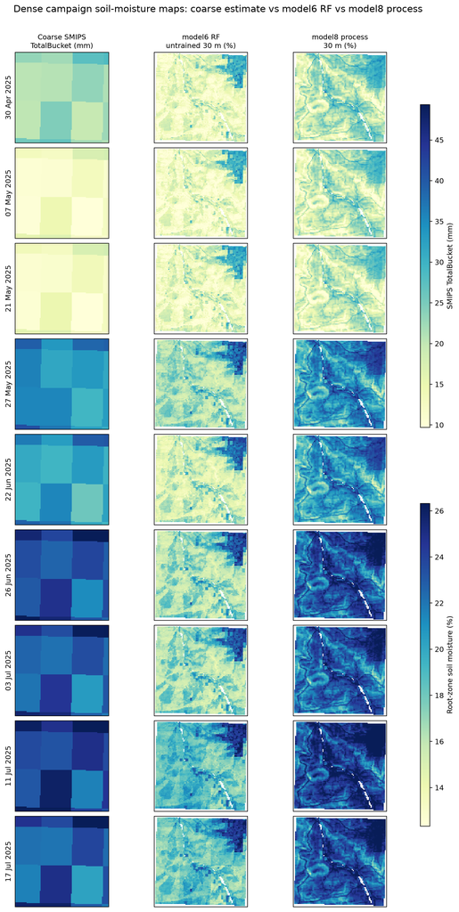

Coarse SMIPS beside model6 and model8 untrained outputs

## Overall skill

| model | n | NSE/R² | Pearson r | RMSE | ubRMSE | bias | MAE |
| --- | --- | --- | --- | --- | --- | --- | --- |
| model6 RF | 560 | 0.023 | 0.238 | 6.477 | 6.453 | -0.558 | 5.209 |
| model8 process | 560 | 0.031 | 0.462 | 6.452 | 5.884 | 2.645 | 5.199 |

Overall, the two models are close in RMSE/MAE. Model8 has slightly better NSE/R² and RMSE, and substantially higher Pearson correlation, suggesting it captures more temporal/relative variation. However, model8 also has a clear wet bias of about +2.65 percentage points.

The paired comparison is essentially a tie:

| comparison | matched rows | mean Δ absolute error | 95% CI | fraction model6 lower abs error |
| --- | --- | --- | --- | --- |
| model6 RF - model8 process | 560 | 0.010 | -0.408 to 0.467 | 0.516 |

Positive Δ absolute error means model8 is better; negative means model6 is better. The confidence interval spans zero.

## Seasonal skill

The dense campaign only spans autumn and winter.

| model | season | n | NSE/R² | Pearson r | RMSE | ubRMSE | bias |
| --- | --- | --- | --- | --- | --- | --- | --- |
| model6 RF | autumn | 308 | -0.030 | 0.100 | 7.279 | 7.273 | 0.296 |
| model8 process | autumn | 308 | 0.027 | 0.336 | 7.076 | 6.777 | 2.033 |
| model6 RF | winter | 252 | -0.292 | 0.111 | 5.336 | 5.090 | -1.601 |
| model8 process | winter | 252 | -0.421 | 0.355 | 5.595 | 4.448 | 3.394 |

Seasonally, model8 is better in autumn by RMSE/NSE, while model6 is better in winter by RMSE/NSE. Model8 maintains higher Pearson correlation in both seasons but is consistently wetter, especially in winter.

Seasonal bias amplitude is lower for model8 (1.36) than model6 (1.90), but this is because model8 remains positively biased in both seasons. Model6 switches from a slight autumn wet bias to a winter dry bias.

## Dry/wet regime bias

| model | observed moisture quantile | bias | RMSE |
| --- | --- | --- | --- |
| model6 RF | dry q1 | 7.270 | 8.019 |
| model8 process | dry q1 | 8.277 | 9.030 |
| model6 RF | wet q4 | -7.907 | 8.949 |
| model8 process | wet q4 | -3.622 | 6.188 |

Both models overpredict the driest observations and underpredict the wettest observations. Model6 has the stronger compression problem: it is less wet-biased overall but much more strongly underpredicts the wettest quartile. Model8 also overpredicts dry soils, but handles wet observations better.

## Terrain-stratified paired comparison

Negative Δ absolute error means model6 has lower absolute error; positive means model8 has lower absolute error.

Most model8-favouring strata:

| terrain stratum | mean Δ absolute error | model6 RMSE | model8 RMSE | interpretation |
| --- | --- | --- | --- | --- |
| high soil sand | 1.571 | 7.243 | 5.609 | model8 much better |
| high HLI | 1.349 | 7.043 | 5.808 | model8 better on high heat-load terrain |
| low soil clay | 1.112 | 7.025 | 5.883 | model8 better on lower clay / sandier soils |
| high northness | 1.067 | 7.004 | 5.792 | model8 better on high-northness strata |
| high rain_7 | 0.845 | 5.280 | 4.337 | model8 better in recent-rain high strata |

Most model6-favouring strata:

| terrain stratum | mean Δ absolute error | model6 RMSE | model8 RMSE | interpretation |
| --- | --- | --- | --- | --- |
| low soil sand | -1.281 | 6.251 | 7.350 | model6 better |
| high soil clay | -1.124 | 6.251 | 7.235 | model6 better on clayier strata |
| low rain_7 | -0.962 | 6.603 | 7.340 | model6 better in low recent-rain strata |
| mid HLI | -0.828 | 5.864 | 6.703 | model6 better |
| high soil bulk density | -0.762 | 6.362 | 7.124 | model6 better |

The strongest terrain signal is soil-texture-like: model8 improves over model6 in sandier / lower-clay strata and degrades in lower-sand / higher-clay strata. That is consistent with model8 using SLGA soil terms inside a process-model readout. The process model may be capturing a more physically coherent wetness trajectory, but its local soil-level/readout offset is not yet calibrated for this site.

## Key diagnostics

### Paired point-level error difference

Negative values mean model6 is better at that point; positive values mean model8 is better.

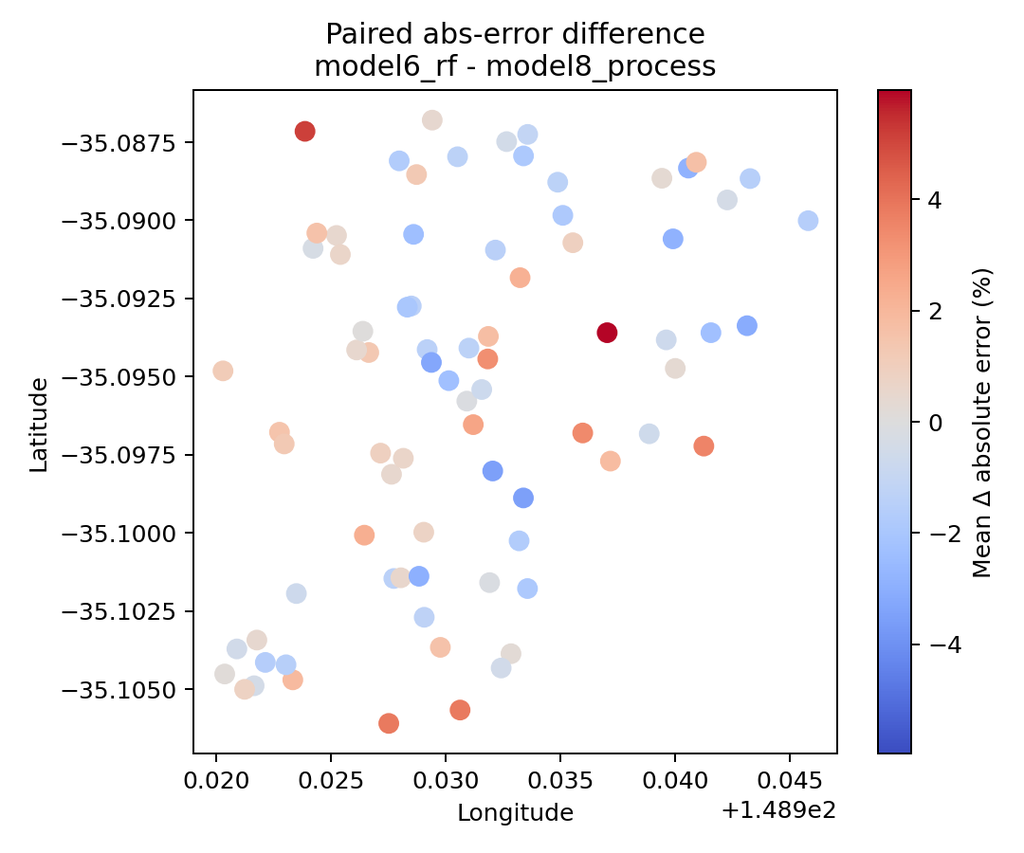

Paired model error-difference map

### Observed vs predicted time series

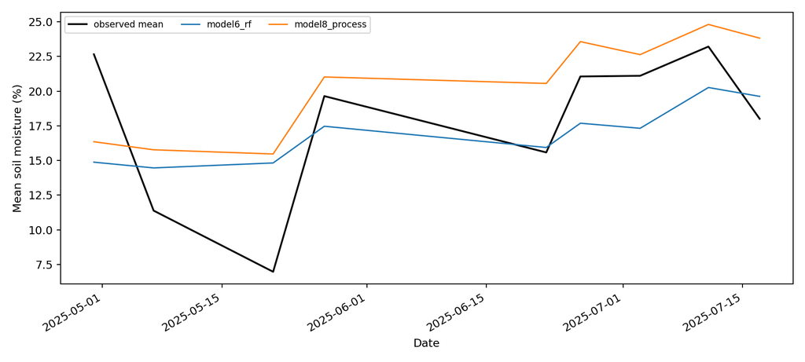

Observed vs predicted time series

### Residual time series

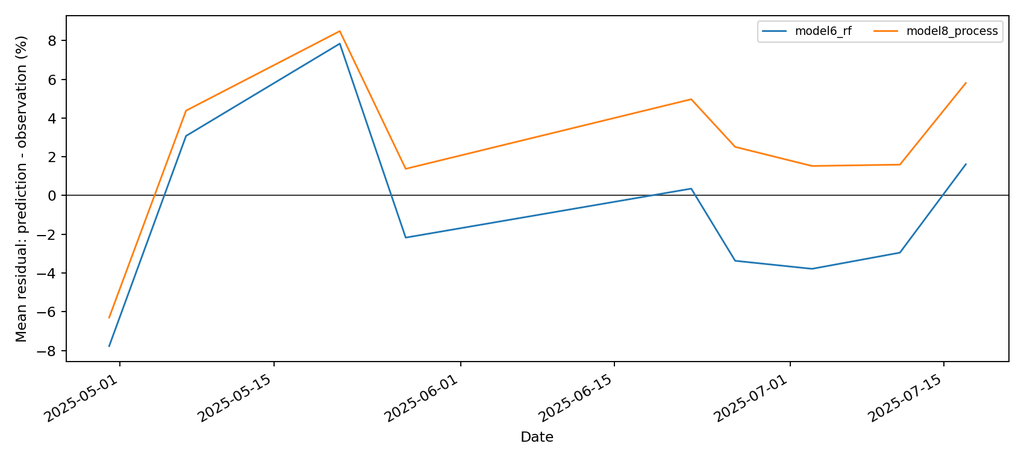

Residual time series

### Seasonal bias

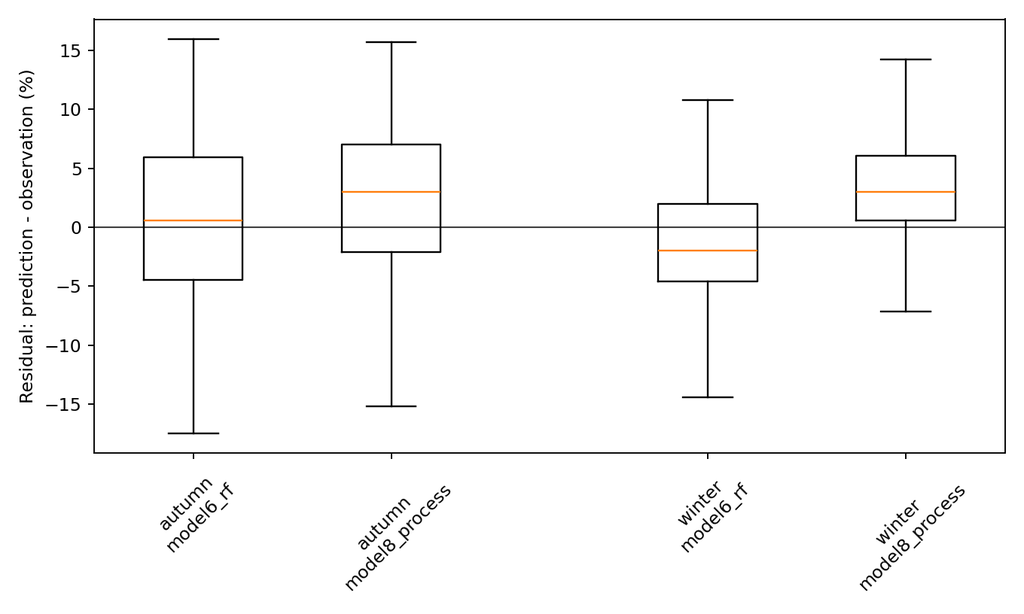

Seasonal bias boxplot

### Observed vs predicted scatter by season

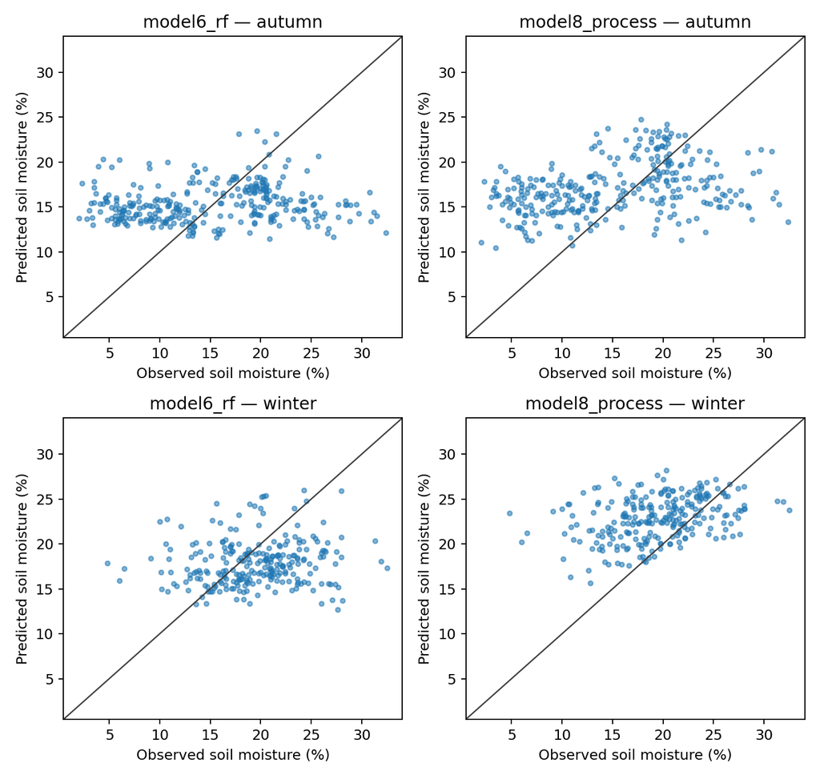

Observed vs predicted scatter by season

## Interpretation

This first model6-vs-model8 dense validation does not show a decisive overall winner. Model8 has better correlation, slightly better overall RMSE/NSE, and better wet-quartile behaviour. Model6 has less overall bias and slightly better winter RMSE.

Scientifically, the most interesting result is the model disagreement structure: model8 appears stronger in high-HLI, high-sand / low-clay, and wetter recent-rain strata, while model6 is stronger in clayier, lower-sand and some lower-rain strata. This is exactly the kind of seasonal/terrain-dependent contrast the independent validation protocol was designed to reveal.

## Re-running the validation

Install the validation package locally:

```bash
python -m pip install -e .
```

Run the independent validator on a model-agnostic prediction table:

```bash
dmm-validate-dense \
  --predictions path/to/model_agnostic_predictions.csv \
  --outdir outputs/my_validation_run
```

The validator expects this minimum long-format schema:

```
model_name, point_id, date, lon, lat, obs_sm_pct, pred_sm_pct
```

Optional terrain and meteorology columns are used only for diagnostics and stratification. They are not assumed to be model inputs.

For the framework-oriented README that previously lived at the repo root, see `docs/framework_usage.md`.